# Run Growth Mixture Modelling for RAMP & COPING longitudinal analyses of common mental health symptoms: PHQ

K L Purves

25 August, 2021

# Introduction

## background

This workbook centralises analyses of the PHQ-9 total scores longitudinal analyses in the RAMP and COPING samples - identifying sub classes in overall trajectories of depression symptoms over the first year of the COVID-19 pandemic (Growth Mixture Modelling; GMM). This corresponds with analytic step 2 in the pre-registration for project [“Moderators of symptom trajectories of depression and anxiety during the COVID-19 pandemic”](https://osf.io/jvca5/).

The exploratory approach attempts to decompose heterogeneous trajectories into distinct subclasses.

Variance was constrained to zero for the 4th linear trajectory as this is only estimated using two time points, and cannot converge otherwise. variances for each intercept and slope were freely estimated for all sub groups.

Best fit model from the 1 class lgcm performed (relating to step 1 in the pre-registration) was a piecewise model, with each inflection point dictated by an imposition or easing of lockdown restrictions, allowing for residuals to correlate between contiguous time points.

## Analytic steps

**global MPlus** All models will be run using Robust Full Information Maximum Likelihood estimation (MLR in MPlus) to account for missing data (assumed missing at random) robust to skewing of the data.

In order to avoid a global maxima/local solution problem (log likelihood depends on starting values used, thus could have a false maximum or sub-optimal model) we will use multiple random sets of starting values, and ensure the highest log likelihood is replicated at least twice (using OPTSEED in MPlus). In practice, we will use 500 random sets of starting values, and carry forward the 125 values with the highest log likelihood to final stage optimisations. This will be set using STARTS = 500 125 in Mplus input scripts. This should ensure global maxima are achieved, whilst balancing computational requirements.

*note: in our pre-registration we specified STARTS 1000 250, however this proved computationally impossible. Thus we ran with half the number of random starts. Providing these replicate, we will still perform two further replications of the best likelihood from our selected model using OPTSEED to ensure there is no evidence for the local maxima problem*

**Step 1. Test a k + 1 class model, starting with k=1 (2 classes tested), of the best fit latent growth curve model established in step 1 (lgcm) until any of the following conditions are met:**

- Indices of model fit show a deterioration in fit according to the BIC relative to a model with fewer classes. The first model (2 class) will be compared to the lgcm (1 class), and so forth.
- The model no longer converges due to complexity
- We exceed 7 classes (this is the maximum number of classes that would be practically useful and logically interpretable).
- If the BIC continues to decrease up until 7 classes, then the best model will be ascertained by first examining the proportion of the sample that has been allocated to the smallest trajectory group. If this is < 1%, then the previous class solution will be preferred.
- If BIC decreases up until 7 class solution, and all classes contain > 1% of the data, then the best model will be selected by creating a scree plot of BIC values. the model that falls at the inflection point (or the point of diminishing gains) will be selected (see pre registration for citations).
- if inflection point remains ambiguous, then remaining fit indices will be compared globally to select between two similar models. The model with the highest entropy will be selected preferentially. If entropy is equivalent, then model which has better fit on the most number of fit indices (described below) will be selected.

**Step 2. Assess overall fit of the selected model to ensure it is the best and most parsimonious solution** * We will ensure there is no evidence for the local maxima problem by rerunning the analysis using the top two seeds from the replicated best log likelihood from the original analysis using OPTSEED in a new Mplus input file. We will check that the best log likelihood from this output matches that from the previous output. We will include TECH11 output in this MPLUS run to output the Vuong-Lo-Mendell-Rubin Likelihood ratios test comparing the best fit model to the earlier fit model

- We will run a second analysis using OPTSEED to be even more sure there is no evidence for the local maxima problem by rerunning the analysis using the top two seeds from the replicated best log likelihood from the original analysis in a new Mplus input file. We will check that the best log likelihood from this output matches that from the previous output. We will include TECH14 output in this MPLUS run to output the Bootstrapped Likelihood ratios test (BLRT) comparing the best fit model to the earlier nested model. *NOTE: Mplus forum suggests BLRT p-values often remain at 0 even when an unreasonable number of classes is tested. Given this, may consider not running this if computational time is unfeasible*

This step wise procedure should save time whilst ensuring we select the optimal model and obtain unbiased estimates. [see this webnote for a description of the step wise procedure](https://www.statmodel.com/examples/webnotes/webnote14.pdf).

- assuming model selection was unambiguous, assess model fit indices globally to ensure all indicators are reasonable
- assuming above is true, check smallest group has >1% of the sample
- assess parsimony of the model. Does it divide one trajectory into two which only differ in intercept?
- Assess entropy. If less than <0.8, ensure appropriate discussion of this limitation of class assignment. Consider impact of accuracy of class assignment on any subsequent predictive steps

## fit indices that will be used to identify the best model

See pre registration for detailed description of all outcomes.

- Bayesian Information Criterion (BIC). Decisions of best model will be primarily based on this. Smaller value = better fit
- Aikaike Information Criterion (AIC). Smaller value = better fit
- Likelihood ratio test (LRT) P > 0.05 indicates better model

# Setup

```r
# clear global environment
remove(list = ls())
```

*note: some of the install and update processes require command line verification in the console. If you are running this script for the first time and it does not proceed, open and check the console*

*colour paletttes and plot label list* RAMP colours (first two) and then a complementary palette of distinguishable colours that seem to be distinguishable in the case of colourblindness too [see this website to simulate the colours under different colour blindness conditions](https://coolors.co/4ed1b7-f6c66a-3066be-d90368-1b2d2a-4c2e05-c98686)

# Step 1: run a K+1 class analysis

Will run each class consecutively, to check model for clear indications of stopping points defined above.

## Two classes

### run model

note, make sure eval=false in this block in final version to ensure script can be knitted even on a computer without mplus.

```r
runModels("./MPlus_input_gmm/PHQ/phq_GMM_piecewise_2_classes.inp",
          recursive = FALSE,
          showOutput=TRUE,
          replaceOutfile="never"
          )
```

### Evaluate model

#### Compare BIC of current and previous model

##### call in data from previous model

```r
depression.one.class.out <- readModels("./MPlus_input_lgcm/PHQ/phq_latentGrowthCurve_piecewise_wPairwise_correlations.out",
                           recursive=FALSE)
```

##### call in data from current model

```r
depression.two.class.out <- readModels("./MPlus_input_gmm/PHQ/phq_GMM_piecewise_2_classes.out",
                           recursive=FALSE)
```

##### extract BIC

```r
justBIC_one_class <- depression.one.class.out$summaries  %>%
  select(c("Title",  "BIC", "aBIC")) %>%
  arrange(BIC)
```

```r
justBIC_two_class <- depression.two.class.out$summaries  %>%
  select(c("Title",  "BIC", "aBIC")) %>%
  arrange(BIC)
```

##### compare

```r
BIC_one_two_compare <- rbind(justBIC_one_class,
                         justBIC_two_class)

BIC_one_two_compare
```

| Title | BIC | aBIC |
| --- | --- | --- |
| Depression symptoms in RAMP and COPING piecewise trajectories With pairwise correlations | 1770568 | 1770422 |
| Depression Symptoms in RAMP & COPING 2 class solution | 1761678 | 1761513 |

Difference in BIC

```r
BIC_one_two_compare$BIC[1] - BIC_one_two_compare$BIC[2]
```

[1] 8889.944

Difference in sample size adjusted BIC

```r
BIC_one_two_compare$aBIC[1] - BIC_one_two_compare$aBIC[2]
```

[1] 8909.012

## Three classes

### run model

note, make sure eval=false in this block in final version to ensure script can be knitted even on a computer without mplus.

```r
runModels("./MPlus_input_gmm/PHQ/phq_GMM_piecewise_3_classes.inp",
          recursive = FALSE,
          showOutput=TRUE,
          replaceOutfile="never")
```

### Evaluate model

#### Compare BIC of current and previous model

##### call in data from current model

```r
depression.three.class.out <- readModels("./MPlus_input_gmm/PHQ/phq_GMM_piecewise_3_classes.out",
                           recursive=FALSE)
```

##### extract BIC

```r
justBIC_three_class <- depression.three.class.out$summaries  %>%
  select(c("Title",  "BIC", "aBIC")) %>%
  arrange(BIC)
```

##### compare

```r
BIC_two_three_compare <- rbind(justBIC_two_class,
                         justBIC_three_class)
BIC_two_three_compare
```

| Title | BIC | aBIC |
| --- | --- | --- |
| Depression Symptoms in RAMP & COPING 2 class solution | 1761678 | 1761513 |
| Depression Symptoms in RAMP & COPING 3 class solution | 1758133 | 1757949 |

Difference in BIC

```r
BIC_two_three_compare$BIC[1] - BIC_two_three_compare$BIC[2]
```

[1] 3545.088

Difference in sample size adjusted BIC

```r
BIC_two_three_compare$aBIC[1] - BIC_two_three_compare$aBIC[2]
```

[1] 3564.155

## four classes

### run model

note, make sure eval=false in this block in final version to ensure script can be knitted even on a computer without mplus.

```r
runModels("./MPlus_input_gmm/PHQ/phq_GMM_piecewise_4_classes.inp",
          recursive = FALSE,
          showOutput=TRUE,
          replaceOutfile="never")
```

### Evaluate model

#### Compare BIC of current and previous model

##### call in data from current model

```r
depression.four.class.out <- readModels("./MPlus_input_gmm/PHQ/phq_GMM_piecewise_4_classes.out",
                           recursive=FALSE)
```

##### extract BIC

```r
justBIC_four_class <- depression.four.class.out$summaries  %>%
  select(c("Title",  "BIC", "aBIC")) %>%
  arrange(BIC)
```

##### compare

```r
BIC_three_four_compare <- rbind(justBIC_three_class,
                         justBIC_four_class)

BIC_three_four_compare
```

| Title | BIC | aBIC |
| --- | --- | --- |
| Depression Symptoms in RAMP & COPING 3 class solution | 1758133 | 1757949 |
| Depression Symptoms in RAMP & COPING 4 class solution | 1753986 | 1753783 |

Difference in BIC

```r
BIC_three_four_compare$BIC[1] - BIC_three_four_compare$BIC[2]
```

[1] 4146.662

Difference in sample size adjusted BIC

```r
BIC_three_four_compare$aBIC[1] - BIC_three_four_compare$aBIC[2]
```

[1] 4165.731

## five classes

### run model

note, make sure eval=false in this block in final version to ensure script can be knitted even on a computer without mplus.

```r
runModels("./MPlus_input_gmm/PHQ/phq_GMM_piecewise_5_classes.inp",
          recursive = FALSE,
          showOutput=TRUE,
          replaceOutfile="never")
```

### Evaluate model

#### Compare BIC of current and previous model

##### call in data from current model

```r
depression.five.class.out <- readModels("./MPlus_input_gmm/PHQ/phq_GMM_piecewise_5_classes.out",
                           recursive=FALSE)
```

##### extract BIC

```r
justBIC_five_class <- depression.five.class.out$summaries  %>%
  select(c("Title",  "BIC", "aBIC")) %>%
  arrange(BIC)
```

##### compare

```r
BIC_four_five_compare <- rbind(justBIC_four_class,
                         justBIC_five_class)

BIC_four_five_compare
```

| Title | BIC | aBIC |
| --- | --- | --- |
| Depression Symptoms in RAMP & COPING 4 class solution | 1753986 | 1753783 |
| Depression Symptoms in RAMP & COPING 5 class solution | 1751525 | 1751303 |

Difference in BIC

```r
BIC_four_five_compare$BIC[1] - BIC_four_five_compare$BIC[2]
```

[1] 2461.151

Difference in sample size adjusted BIC

```r
BIC_four_five_compare$aBIC[1] - BIC_four_five_compare$aBIC[2]
```

[1] 2480.219

## six classes

### run model

note, make sure eval=false in this block in final version to ensure script can be knitted even on a computer without mplus.

```r
runModels("./MPlus_input_gmm/PHQ/phq_GMM_piecewise_6_classes.inp",
          recursive = FALSE,
          showOutput=TRUE,
          replaceOutfile="never")
```

### Evaluate model

#### Compare BIC of current and previous model

##### call in data from current model

```r
depression.six.class.out <- readModels("./MPlus_input_gmm/PHQ/phq_GMM_piecewise_6_classes.out",
                           recursive=FALSE)
```

##### extract BIC

```r
justBIC_six_class <- depression.six.class.out$summaries  %>%
  select(c("Title",  "BIC", "aBIC")) %>%
  arrange(BIC)
```

##### compare

```r
BIC_five_six_compare <- rbind(justBIC_five_class,
                         justBIC_six_class)

BIC_five_six_compare
```

| Title | BIC | aBIC |
| --- | --- | --- |
| Depression Symptoms in RAMP & COPING 5 class solution | 1751525 | 1751303 |
| Depression Symptoms in RAMP & COPING 6 class solution | 1749392 | 1749150 |

Difference in BIC

```r
BIC_five_six_compare$BIC[1] - BIC_five_six_compare$BIC[2]
```

[1] 2133.67

Difference in sample size adjusted BIC

```r
BIC_five_six_compare$aBIC[1] - BIC_five_six_compare$aBIC[2]
```

[1] 2152.738

## seven classes

### run model

note, make sure eval=false in this block in final version to ensure script can be knitted even on a computer without mplus.

```r
runModels("./MPlus_input_gmm/PHQ/phq_GMM_piecewise_7_classes.inp",
          recursive = FALSE,
          showOutput=TRUE,
          replaceOutfile="never")
```

### Evaluate model

#### Compare BIC of current and previous model

##### call in data from current model

```r
depression.seven.class.out <- readModels("./MPlus_input_gmm/PHQ/phq_GMM_piecewise_7_classes.out",
                           recursive=FALSE)
```

##### extract BIC

```r
justBIC_seven_class <- depression.seven.class.out$summaries  %>%
  select(c("Title",  "BIC", "aBIC")) %>%
  arrange(BIC)
```

##### compare

```r
BIC_six_seven_compare <- rbind(justBIC_six_class,
                         justBIC_seven_class)

BIC_six_seven_compare
```

| Title | BIC | aBIC |
| --- | --- | --- |
| Depression Symptoms in RAMP & COPING 6 class solution | 1749392 | 1749150 |
| Depression Symptoms in RAMP & COPING 7 class solution | 1747535 | 1747275 |

Difference in BIC

```r
BIC_six_seven_compare$BIC[1] - BIC_six_seven_compare$BIC[2]
```

[1] 1856.548

Difference in sample size adjusted BIC

```r
BIC_six_seven_compare$aBIC[1] - BIC_six_seven_compare$aBIC[2]
```

[1] 1875.615

# Step 2: Assess overall fit of the selected model

## Check for local maxima problem (replicate best log likelihood) and perform Likelihood ratio tests

# Supplementary checks, tables and figures

## fit indices for all models run

read all GMM models. Note that I copy each output into an output folder for this step as the extra output that is generated while the scripts are running throws errors. When all models are run, it will be easier to delete the output art of this file reference, and get rid of those duplicates.

It’s likely that to do so, you will need to specify what output gets read in in this next step using the “what = c(”summaries“,”class_counts") command to avoid reading in any .dat files generated.

```r
depression.all.out <- readModels("./MPlus_input_gmm/PHQ/output",
                           recursive=FALSE)
```

extract relevant summaries from GMM and 1 class lgcm

```r
justSummariesGMM <- do.call("rbind.fill",
  sapply(depression.all.out ,"[", "summaries")) %>%
  select(c("Title", "Parameters",  "Entropy", "AIC", "BIC","aBIC", "LL")) %>%
  arrange(BIC)
```

extract the same from the one trajectory lgcm

```r
justSummarieslgcm <- depression.one.class.out$summaries %>%
  select(c("Title", "Parameters", "AIC", "BIC","aBIC", "LL")) %>%
  arrange(BIC)

justSummarieslgcm$Entropy <- "1"

justSummarieslgcm <- justSummarieslgcm %>%
  relocate(Entropy, .after=Parameters)
```

And bind these together to print in a nice table

```r
justSummaries <- rbind(justSummariesGMM,justSummarieslgcm) %>%
  arrange(BIC)

summary_table <- justSummaries %>%
  kbl(caption ="Growth mixture modelling fit statistics for all models tested: PHQ",
        align='lcccccc') %>%
  kable_styling()

summary_table
```

Growth mixture modelling fit statistics for all models tested: PHQ

| Title | Parameters | Entropy | AIC | BIC | aBIC | LL |
| --- | --- | --- | --- | --- | --- | --- |
| Depression Symptoms in RAMP & COPING 7 class solution | 82 | 0.743 | 1746826 | 1747535 | 1747275 | -873331.1 |
| Depression Symptoms in RAMP & COPING 6 class solution | 76 | 0.745 | 1748735 | 1749392 | 1749150 | -874291.3 |
| Depression Symptoms in RAMP & COPING 5 class solution | 70 | 0.744 | 1750920 | 1751525 | 1751303 | -875390.1 |
| Depression Symptoms in RAMP & COPING 4 class solution | 64 | 0.772 | 1753433 | 1753986 | 1753783 | -876652.6 |
| Depression Symptoms in RAMP & COPING 3 class solution | 58 | 0.776 | 1757632 | 1758133 | 1757949 | -878757.8 |
| Depression Symptoms in RAMP & COPING 2 class solution | 52 | 0.763 | 1761229 | 1761678 | 1761513 | -880562.3 |
| Depression symptoms in RAMP and COPING piecewise trajectories With pairwise correlations | 46 | 1 | 1770170 | 1770568 | 1770422 | -885039.2 |

## Class counts for each model run

Particularly need to make sure that the selected model has >1% of the sample in the smallest class.

2 class

```r
class_allocation_2 <- depression.all.out$phq_GMM_piecewise_2_classes.out$class_counts$mostLikely %>%
  kbl(caption = "Counts and proportions of most likely class membership: Two class solution",
        align='lll',
        digits = 2,
        col.names = str_to_title(gsub("[.]", " ", names(depression.all.out$phq_GMM_piecewise_2_classes.out$class_counts$mostLikely)))) %>%
  kable_styling(position = "left",
                "striped")

class_allocation_2
```

Counts and proportions of most likely class membership: Two class solution

| Class | Count | Proportion |
| --- | --- | --- |
| 1 | 31854 | 0.76 |
| 2 | 10152 | 0.24 |

3 class

```r
class_allocation_3 <- depression.all.out$phq_GMM_piecewise_3_classes.out$class_counts$mostLikely %>%
  kbl(caption = "Counts and proportions of most likely class membership: Three class solution",
        align='lll',
        digits = 2,
        col.names = str_to_title(gsub("[.]", " ", names(depression.all.out$phq_GMM_piecewise_3_classes.out$class_counts$mostLikely)))) %>%
  kable_styling(position = "left",
                "striped")

class_allocation_3
```

Counts and proportions of most likely class membership: Three class solution

| Class | Count | Proportion |
| --- | --- | --- |
| 1 | 8500 | 0.20 |
| 2 | 3203 | 0.08 |
| 3 | 30303 | 0.72 |

4 class

```r
class_allocation_4 <- depression.all.out$phq_GMM_piecewise_4_classes.out$class_counts$mostLikely %>%
  kbl(caption = "Counts and proportions of most likely class membership: Four class solution",
        align='lll',
        digits = 2,
        col.names = str_to_title(gsub("[.]", " ", names(depression.all.out$phq_GMM_piecewise_4_classes.out$class_counts$mostLikely)))) %>%
  kable_styling(position = "left",
                "striped")

class_allocation_4
```

Counts and proportions of most likely class membership: Four class solution

| Class | Count | Proportion |
| --- | --- | --- |
| 1 | 4341 | 0.10 |
| 2 | 25364 | 0.60 |
| 3 | 6977 | 0.17 |
| 4 | 5324 | 0.13 |

5 class

```r
class_allocation_5 <- depression.all.out$phq_GMM_piecewise_5_classes.out$class_counts$mostLikely %>%
  kbl(caption = "Counts and proportions of most likely class membership: Five class solution",
        align='lll',
        digits = 2,
        col.names = str_to_title(gsub("[.]", " ", names(depression.all.out$phq_GMM_piecewise_5_classes.out$class_counts$mostLikely)))) %>%
  kable_styling(position = "left",
                "striped")

class_allocation_5
```

Counts and proportions of most likely class membership: Five class solution

| Class | Count | Proportion |
| --- | --- | --- |
| 1 | 4540 | 0.11 |
| 2 | 26291 | 0.63 |
| 3 | 4480 | 0.11 |
| 4 | 3318 | 0.08 |
| 5 | 3377 | 0.08 |

6 class

```r
class_allocation_6 <- depression.all.out$phq_GMM_piecewise_6_classes.out$class_counts$mostLikely %>%
  kbl(caption = "Counts and proportions of most likely class membership: Six class solution",
        align='lll',
        digits = 2,
        col.names = str_to_title(gsub("[.]", " ", names(depression.all.out$phq_GMM_piecewise_6_classes.out$class_counts$mostLikely)))) %>%
  kable_styling(position = "left",
                "striped")

class_allocation_6
```

Counts and proportions of most likely class membership: Six class solution

| Class | Count | Proportion |
| --- | --- | --- |
| 1 | 4772 | 0.11 |
| 2 | 1504 | 0.04 |
| 3 | 3843 | 0.09 |
| 4 | 2097 | 0.05 |
| 5 | 26284 | 0.63 |
| 6 | 3506 | 0.08 |

7 class

```r
class_allocation_7 <- depression.all.out$phq_GMM_piecewise_7_classes.out$class_counts$mostLikely %>%
  kbl(caption = "Counts and proportions of most likely class membership: Seven class solution",
        align='lll',
        digits = 2,
        col.names = str_to_title(gsub("[.]", " ", names(depression.all.out$phq_GMM_piecewise_7_classes.out$class_counts$mostLikely)))) %>%
  kable_styling(position = "left",
                "striped")

class_allocation_7
```

Counts and proportions of most likely class membership: Seven class solution

| Class | Count | Proportion |
| --- | --- | --- |
| 1 | 2252 | 0.05 |
| 2 | 1587 | 0.04 |
| 3 | 26245 | 0.62 |
| 4 | 4796 | 0.11 |
| 5 | 2832 | 0.07 |
| 6 | 1080 | 0.03 |
| 7 | 3214 | 0.08 |

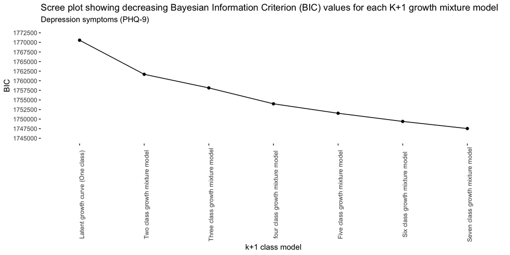

```r
# reorder the title column by BIC for plotting
justSummaries$Title <-  reorder(justSummaries$Title, -justSummaries$BIC)

BIC_scree_plot <- ggplot() +
  geom_line(data =justSummaries,
        aes(x = Title, y = BIC,group=1)) +
  scale_y_continuous(limits =c(1745000,1772500), breaks = seq(1745000,1772500,by=2500)) +
  scale_x_discrete(name="k+1 class model",labels=c("Latent growth curve (One class)","Two class growth mixture model","Three class growth mixture model","four class growth mixture model","Five class growth mixture model","Six class growth mixture model","Seven class growth mixture model")) +
  geom_point(data = justSummaries,
        aes(x = Title, y = BIC,group=1), show.legend = F) +
  labs(title="Scree plot showing decreasing Bayesian Information Criterion (BIC) values for each K+1 growth mixture model",
       subtitle="Depression symptoms (PHQ-9)",
         y ="BIC") +
  theme(panel.background = element_blank(),
        axis.text.x = element_text(angle = 90))

BIC_scree_plot
```

## Save supplementary tables and figures

```r
# set up folder reference
save_file_path <- file.path(dirname(dirname(getwd())),"output/supplementary_tables_figures/PHQ/")

# save summary table
save_kable(summary_table,
           file.path(save_file_path,"phq_gmm_allModelsfitStatistics.html"))

# save BIC scree
ggsave(
  filename=file.path(save_file_path,"phq_BIC_scree_plot.png"),
  plot =BIC_scree_plot)
# save class proportion data tables
save_kable(class_allocation_2,
           file.path(save_file_path,"phq_gmm_class_allocation_numbers_2class.html"))

save_kable(class_allocation_3,
           file.path(save_file_path,"phq_gmm_class_allocation_numbers_3class.html"))

save_kable(class_allocation_4,
           file.path(save_file_path,"phq_gmm_class_allocation_numbers_4class.html"))

save_kable(class_allocation_5,
           file.path(save_file_path,"phq_gmm_class_allocation_numbers_5class.html"))

save_kable(class_allocation_6,
           file.path(save_file_path,"phq_gmm_class_allocation_numbers_6class.html"))

save_kable(class_allocation_7,
           file.path(save_file_path,"phq_gmm_class_allocation_numbers_7class.html"))
```

# Plots

## One classes

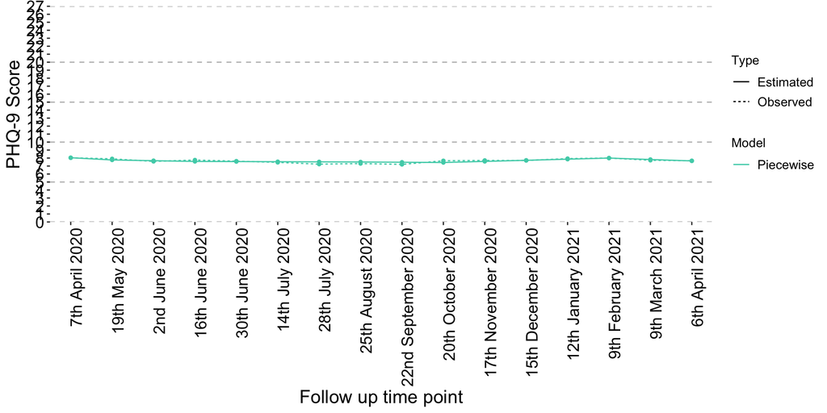

```r
growth_curves_oneclass <- ggplot() +
  geom_line(data = dat_plot_curves_1,
        aes(x = timepoint, y = score, colour = Model,linetype=Type)) +
  geom_point(data = dat_plot_curves_1,
        aes(x = timepoint, y = score, colour = Model, shape=Model), show.legend = F) +
  scale_color_manual(values = pres.palette) +
  labs(x = "Follow up time point", y ="PHQ-9 Score") +
  scale_y_continuous(expand = c(0,0), limits = c(0,27), breaks=seq(0, 27, 1)) +
  scale_x_continuous(expand = c(0,0), limits = c(-0.5,15.5), breaks=seq(0, 15, by = 1),
                   labels = timepoint_list) +
  geom_hline(yintercept=0, linetype="dashed", color = "grey") +
  geom_hline(yintercept=27, linetype="dashed", color = "grey") +
  geom_hline(yintercept=5, linetype="dashed", color = "grey") +
  geom_hline(yintercept=10, linetype="dashed", color = "grey") +
  geom_hline(yintercept=15, linetype="dashed", color = "grey") +
  geom_hline(yintercept=20, linetype="dashed", color = "grey") +
  theme(panel.grid.major.y = element_blank(),
        axis.text = element_text(colour="black", size = 14),
        axis.title = element_text(colour="black", size = 16),
        axis.text.x = element_text(angle = 90,
        hjust=1),
        legend.key = element_blank(),
        legend.text = element_text(colour = "black", size = 11),
        panel.background = element_blank())

growth_curves_oneclass
```

## Two classes

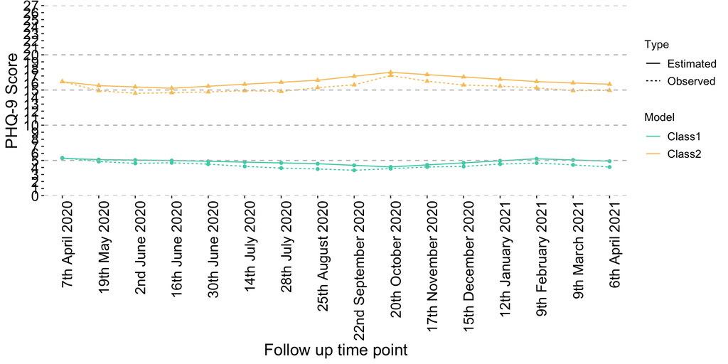

```r
growth_curves_twoclass <- ggplot() +
  geom_line(data = dat_plot_curves_two,
        aes(x = timepoint, y = score, colour = Model,linetype=Type)) +
  geom_point(data = dat_plot_curves_two,
        aes(x = timepoint, y = score, colour = Model, shape=Model), show.legend = F) +
  scale_color_manual(values = pres.palette) +
  labs(x = "Follow up time point", y ="PHQ-9 Score") +
  scale_y_continuous(expand = c(0,0), limits = c(0,27), breaks=seq(0,27, 1)) +
  scale_x_continuous(expand = c(0,0), limits = c(-0.5,15.5), breaks=seq(0, 15, by = 1),
                   labels = timepoint_list) +
   geom_hline(yintercept=0, linetype="dashed", color = "grey") +
  geom_hline(yintercept=27, linetype="dashed", color = "grey") +
  geom_hline(yintercept=5, linetype="dashed", color = "grey") +
  geom_hline(yintercept=10, linetype="dashed", color = "grey") +
  geom_hline(yintercept=15, linetype="dashed", color = "grey") +
  geom_hline(yintercept=20, linetype="dashed", color = "grey") +
  theme(panel.grid.major.y = element_blank(),
        axis.text = element_text(colour="black", size = 14),
        axis.title = element_text(colour="black", size = 16),
        axis.text.x = element_text(angle = 90,
        hjust=1),
        legend.key = element_blank(),
        legend.text = element_text(colour = "black", size = 11),
        panel.background = element_blank())

growth_curves_twoclass
```

## three classes

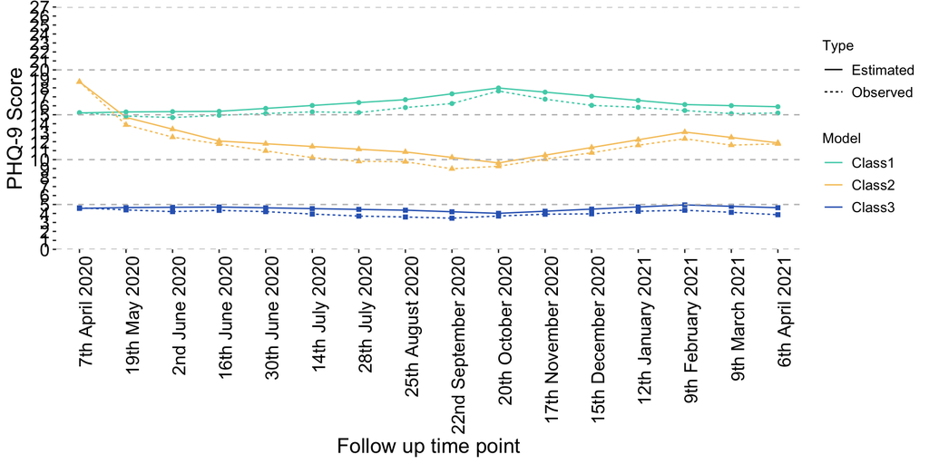

```r
growth_curves_threeclass <- ggplot() +
  geom_line(data = dat_plot_curves_three,
        aes(x = timepoint, y = score, colour = Model,linetype=Type)) +
  geom_point(data = dat_plot_curves_three,
        aes(x = timepoint, y = score, colour = Model, shape=Model), show.legend = F) +
  scale_color_manual(values = pres.palette) +
  labs(x = "Follow up time point", y ="PHQ-9 Score") +
  scale_y_continuous(expand = c(0,0), limits = c(0,27), breaks=seq(0,27, 1)) +
  scale_x_continuous(expand = c(0,0), limits = c(-0.5,15.5), breaks=seq(0, 15, by = 1),
                   labels = timepoint_list) +
 geom_hline(yintercept=0, linetype="dashed", color = "grey") +
  geom_hline(yintercept=27, linetype="dashed", color = "grey") +
  geom_hline(yintercept=5, linetype="dashed", color = "grey") +
  geom_hline(yintercept=10, linetype="dashed", color = "grey") +
  geom_hline(yintercept=15, linetype="dashed", color = "grey") +
  geom_hline(yintercept=20, linetype="dashed", color = "grey") +
  theme(panel.grid.major.y = element_blank(),
        axis.text = element_text(colour="black", size = 14),
        axis.title = element_text(colour="black", size = 16),
        axis.text.x = element_text(angle = 90,
        hjust=1),
        legend.key = element_blank(),
        legend.text = element_text(colour = "black", size = 11),
        panel.background = element_blank())

growth_curves_threeclass
```

## four classes

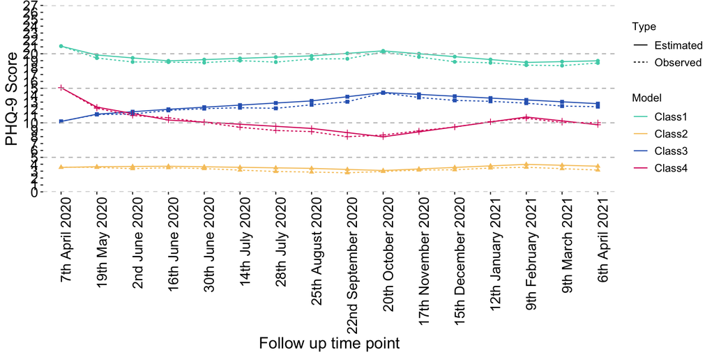

```r
growth_curves_fourclass <- ggplot() +
  geom_line(data = dat_plot_curves_four,
        aes(x = timepoint, y = score, colour = Model,linetype=Type)) +
  geom_point(data = dat_plot_curves_four,
        aes(x = timepoint, y = score, colour = Model, shape=Model), show.legend = F) +
  scale_color_manual(values = pres.palette) +
  labs(x = "Follow up time point", y ="PHQ-9 Score") +
  scale_y_continuous(expand = c(0,0), limits = c(0,27), breaks=seq(0,27, 1)) +
  scale_x_continuous(expand = c(0,0), limits = c(-0.5,15.5), breaks=seq(0, 15, by = 1),
                   labels = timepoint_list) +
 geom_hline(yintercept=0, linetype="dashed", color = "grey") +
  geom_hline(yintercept=27, linetype="dashed", color = "grey") +
  geom_hline(yintercept=5, linetype="dashed", color = "grey") +
  geom_hline(yintercept=10, linetype="dashed", color = "grey") +
  geom_hline(yintercept=15, linetype="dashed", color = "grey") +
  geom_hline(yintercept=20, linetype="dashed", color = "grey") +
  theme(panel.grid.major.y = element_blank(),
        axis.text = element_text(colour="black", size = 14),
        axis.title = element_text(colour="black", size = 16),
        axis.text.x = element_text(angle = 90,
        hjust=1),
        legend.key = element_blank(),
        legend.text = element_text(colour = "black", size = 11),
        panel.background = element_blank())

growth_curves_fourclass
```

## five classes

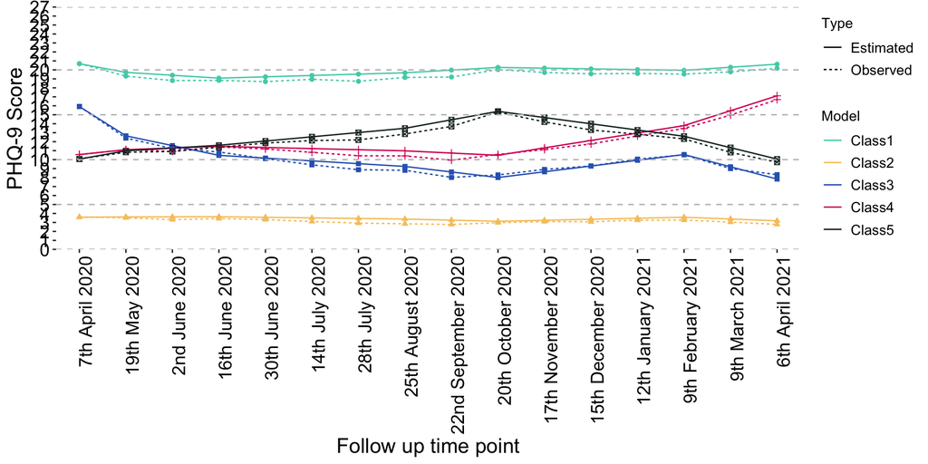

```r
growth_curves_fiveclass <- ggplot() +
  geom_line(data = dat_plot_curves_five,
        aes(x = timepoint, y = score, colour = Model,linetype=Type)) +
  geom_point(data = dat_plot_curves_five,
        aes(x = timepoint, y = score, colour = Model, shape=Model), show.legend = F) +
  scale_color_manual(values = pres.palette) +
  labs(x = "Follow up time point", y ="PHQ-9 Score") +
  scale_y_continuous(expand = c(0,0), limits = c(0,27), breaks=seq(0,27, 1)) +
  scale_x_continuous(expand = c(0,0), limits = c(-0.5,15.5), breaks=seq(0, 15, by = 1),
                   labels = timepoint_list) +
 geom_hline(yintercept=0, linetype="dashed", color = "grey") +
  geom_hline(yintercept=27, linetype="dashed", color = "grey") +
  geom_hline(yintercept=5, linetype="dashed", color = "grey") +
  geom_hline(yintercept=10, linetype="dashed", color = "grey") +
  geom_hline(yintercept=15, linetype="dashed", color = "grey") +
  geom_hline(yintercept=20, linetype="dashed", color = "grey") +
  theme(panel.grid.major.y = element_blank(),
        axis.text = element_text(colour="black", size = 14),
        axis.title = element_text(colour="black", size = 16),
        axis.text.x = element_text(angle = 90,
        hjust=1),
        legend.key = element_blank(),
        legend.text = element_text(colour = "black", size = 11),
        panel.background = element_blank())

growth_curves_fiveclass
```

## six classes

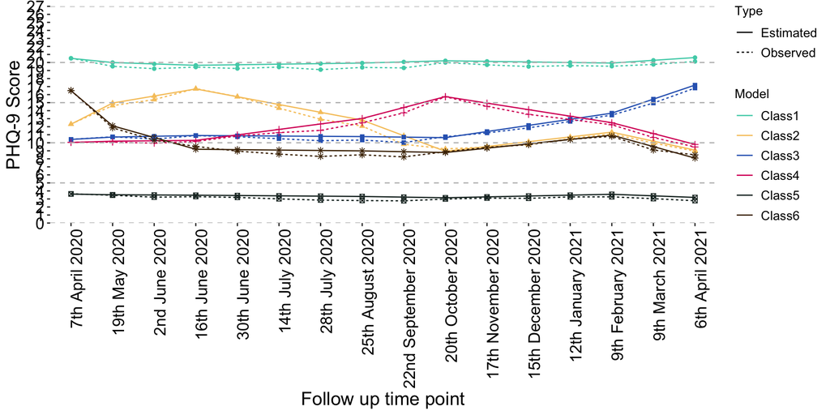

```r
growth_curves_sixclass <- ggplot() +
  geom_line(data = dat_plot_curves_six,
        aes(x = timepoint, y = score, colour = Model,linetype=Type)) +
  geom_point(data = dat_plot_curves_six,
        aes(x = timepoint, y = score, colour = Model, shape=Model), show.legend = F) +
  scale_color_manual(values = pres.palette) +
  labs(x = "Follow up time point", y ="PHQ-9 Score") +
  scale_y_continuous(expand = c(0,0), limits = c(0,27), breaks=seq(0,27, 1)) +
  scale_x_continuous(expand = c(0,0), limits = c(-0.5,15.5), breaks=seq(0, 15, by = 1),
                   labels = timepoint_list) +
 geom_hline(yintercept=0, linetype="dashed", color = "grey") +
  geom_hline(yintercept=27, linetype="dashed", color = "grey") +
  geom_hline(yintercept=5, linetype="dashed", color = "grey") +
  geom_hline(yintercept=10, linetype="dashed", color = "grey") +
  geom_hline(yintercept=15, linetype="dashed", color = "grey") +
  geom_hline(yintercept=20, linetype="dashed", color = "grey") +
  theme(panel.grid.major.y = element_blank(),
        axis.text = element_text(colour="black", size = 14),
        axis.title = element_text(colour="black", size = 16),
        axis.text.x = element_text(angle = 90,
        hjust=1),
        legend.key = element_blank(),
        legend.text = element_text(colour = "black", size = 11),
        panel.background = element_blank())

growth_curves_sixclass
```

## seven classes

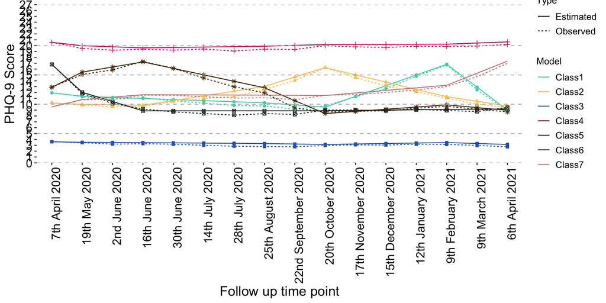

```r
growth_curves_sevenclass <- ggplot() +
  geom_line(data = dat_plot_curves_seven,
        aes(x = timepoint, y = score, colour = Model,linetype=Type)) +
  geom_point(data = dat_plot_curves_seven,
        aes(x = timepoint, y = score, colour = Model, shape=Model), show.legend = F) +
  scale_color_manual(values = pres.palette) +
  labs(x = "Follow up time point", y ="PHQ-9 Score") +
  scale_y_continuous(expand = c(0,0), limits = c(0,27), breaks=seq(0,27, 1)) +
  scale_x_continuous(expand = c(0,0), limits = c(-0.5,15.5), breaks=seq(0, 15, by = 1),
                   labels = timepoint_list) +
  geom_hline(yintercept=0, linetype="dashed", color = "grey") +
  geom_hline(yintercept=27, linetype="dashed", color = "grey") +
  geom_hline(yintercept=5, linetype="dashed", color = "grey") +
  geom_hline(yintercept=10, linetype="dashed", color = "grey") +
  geom_hline(yintercept=15, linetype="dashed", color = "grey") +
  geom_hline(yintercept=20, linetype="dashed", color = "grey") +
  theme(panel.grid.major.y = element_blank(),
        axis.text = element_text(colour="black", size = 14),
        axis.title = element_text(colour="black", size = 16),
        axis.text.x = element_text(angle = 90,
        hjust=1),
        legend.key = element_blank(),
        legend.text = element_text(colour = "black", size = 11),
        panel.background = element_blank())

growth_curves_sevenclass
```

## Save all plots for manuscript or supplementary figures

```r
# set up folder reference
save_file_path <- file.path(dirname(dirname(getwd())),"output/Trajectory_plots/PHQ/")

# save all trajectory plots
ggsave(
  filename=file.path(save_file_path,"phq_oneclass_trajectory.png"),
  plot =growth_curves_oneclass,
  width = 14, height = 10, dpi = 150, units = "in")

ggsave(
  filename=file.path(save_file_path,"phq_twoclass_trajectory.png"),
  plot =growth_curves_twoclass,
  width = 14, height = 10, dpi = 150, units = "in")

ggsave(
  filename=file.path(save_file_path,"phq_threeclass_trajectory.png"),
  plot =growth_curves_threeclass,
  width = 14, height = 10, dpi = 150, units = "in")

ggsave(
  filename=file.path(save_file_path,"phq_fourclass_trajectory.png"),
  plot =growth_curves_fourclass,
  width = 14, height = 10, dpi = 150, units = "in")

ggsave(
  filename=file.path(save_file_path,"phq_fiveclass_trajectory.png"),
  plot =growth_curves_fiveclass,
  width = 14, height = 10, dpi = 150, units = "in")

ggsave(
  filename=file.path(save_file_path,"phq_sixclass_trajectory.png"),
  plot =growth_curves_sixclass,
  width = 14, height = 10, dpi = 150, units = "in")

ggsave(
  filename=file.path(save_file_path,"phq_sevenclass_trajectory.png"),
  plot =growth_curves_sevenclass,
  width = 14, height = 10, dpi = 150, units = "in")
```

# Optimal Class Model: Descriptives

## Means and Variances of Intercept, Slopes